# Exploratory Data Analysis

Jenny Yang

07/10/2022

## Getting started

EDA stands for Exploratory Data Analysis. The purpose of EDA is to perform initial investigation on the data, look for interesting trends, characteristics, and anomalies, usually through statistical graphics, and lay the foundation for more in-depth modelling and statistical tests, which will be covered in the **Regression Analysis** section.

### Loading packages

Now your R environment is all set up! With the prompt in mind, let’s take a look at the data at hand, getting a sense of the distribution and potential relationships between variables. We call this step Exploratory Data Analysis, or EDA. First, let’s load some useful packages. In this tutorial, we will mainly explore and visualize the data using the `tidyverse` package, which includes `ggplot2` that we will be using mainly for graphing.

```r
library(tidyverse)
library(janitor)
library(countrycode)
library(colorblindr)
library(viridis)
```

### Overview of the Data

Recall that our prompt is **Help understand what motivates people to lend money to developing-nation entrepreneurs and what factors are associated with paying these loans.** From the file names, `lender_loans.csv`, `lenders.csv`, and `loans.csv` seem to be three most relevant files to start with. We can take a quick peek at the data before diving deep.

```r
lender_loans <- read_csv("data/lender_loans.csv")
lenders <- read_csv("data/lenders.csv")
loans <- read_csv("data/loans.csv")
str(lender_loans)
str(lenders)
str(loans)
```

There are two parts of the prompt that we need to address, **motivation for lending** and **factors associated with repayment**.

To investigate lenders’ motivations, we can focus on `lender_loans` and `lenders`. Possible helpful variables that associate with each lender can include `whereabouts` (introductory description about lenders), `country_code`(lenders’ country), `occupation` (lenders’ occupation), as well as the time that each lender has been a member of Kiva (variables start with `member_since`). `loan_because` will also be revealing since the lenders are directly stating their reasons for lending. Yet, it is a non-numerical data. So, it requires different analytical approaches that will be covered later in the **Text Analysis** section.

Similarly, variables that will contribute to the repayment can include `loan_amount`, `sector`, `use`, `location.code` (borrowers’ country). A larger `loan_amount` may be a larger investment that is more risky. Certain `sector`s can be more profitable than others, similar with `use`. The macroeconomic environment of a location can be exceptionally critical to the success of borrowers.

There are also some variables that may be relevant to both parts of the prompt, such as the time when the loan request was posted and the loan amount. For instance, in 2008, the world economy underwent a global financial crisis. This may increase the number and amount of loans, yet lenders may feel tight and unwilling to offer help during the hard time. The ripple effect afterwards may also influence the borrowers’ ability to repay the loan. Likewise, a smaller amount of loan could be more likely to receive help and more easily repaid. Yet, these are all inferences we may make that need to be backed up by subsequent data analysis.

## EDA

Now we can step into the real data analysis part. We can look at the general distribution of some crucial variables first.

### – Loan amount –

Let’s start simple. To get a general sense of the loan amount, we can plot a barchart with the `loan_amount` on the x-axis and the count on the y-axis. Barchart is one of the most basic and direct visualization graphs. We can also color the bars to see the proportion of loans in different statuses to add another layer of information.

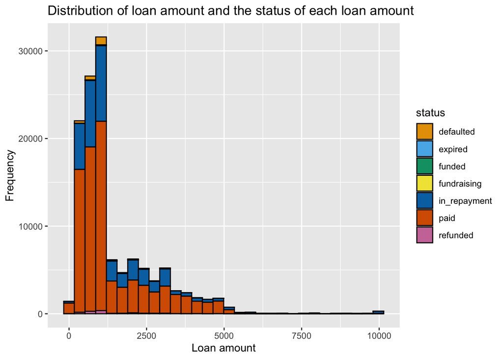

```r
ggplot(lender_loans, aes(x = loan_amount, fill = status, width = 0.1)) +
  geom_bar(stat = "bin", color = "black") +
  xlab("Loan amount") +
  ylab("Frequency") +
  scale_fill_OkabeIto()+
  ggtitle("Distribution of loan amount and the status of each loan amount")
```

From the graph above we can see that the loan amount has a unimodal, skewed right distribution. The majority of loans is concentrated below $1000, while there are some large loans scattered on the right side of the graph. Through the color we can also tell that most loans are already paid, while a good proportion is still in repayment.

A summary table may be more direct to visualize the proportion of each status:

```r
status <- loans %>%
  drop_na(status) %>% # drop missing values by health variable
  group_by(status) %>% # specify categorical variable
  summarize(Frequency = n()) %>% # return counts / frequencies
  mutate(Percent = paste0(round(Frequency / nrow(loans) * 100, 2), "%"))
table1 <- status %>%
  arrange(desc(Percent))
knitr::kable(table1, "pipe")
```

[output not shown]

### – Loan amount and number of loans across year –

We can also put things on a time scale and observe the trend of loan amount and the number of loans over the years. From the barchart below, we can see that both the total loan amount and the number of loans issued each year continued to grow until 2012. The highest loan amount borrowed was in the year 2011 at USD 40.2 million. Similarly, the highest of number of loans were taken in the year 2011 as well, at 30,738 loans. Yet, there was a sharp plummet in 2012. This is because this dataset was obtained in the middle of the year, and the date is up to April 2012. This can be proven by the published Kiva financial accounts online, which states clearly that Kiva’s fiscal year ends on December 31th each year. The data itself also contains clues. For all years under `posted_yr`, the corresponding `posted_month` goes from 1 to 12, except for 2012, where `posted_month` stops at 4. This means that the data include loans from January to December from 2005 to 2011, but for 2012, there’s only data from January up to April. As a result, the data in 2012 may not reflect the whole year’s performance.

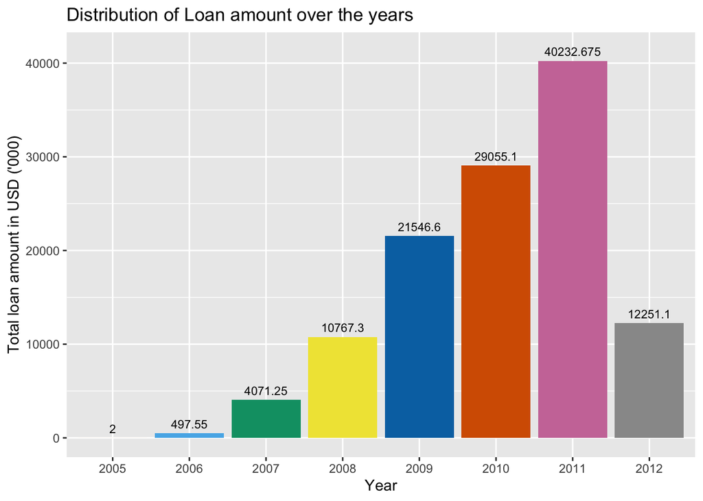

```r
# Summarise loan amount by year
year_loan_amount <- loans %>%
  group_by(posted_yr) %>%
  summarise(Total_amount = sum(loan_amount) / 1000) %>%
  mutate(year = factor(posted_yr, posted_yr))

# Summarise loan count by year
year_loan_count <- loans %>%
  group_by(posted_yr) %>%
  summarise(counts = length(unique(loan_id))) %>%
  mutate(year = factor(posted_yr, posted_yr))

# Clean data
year_loan_amount <- na.omit(year_loan_amount)
year_loan_count <- na.omit(year_loan_count)

par(mfrow = c(1, 1))

# Plot loan amount by year
ggplot(year_loan_amount) +
  aes(x = year, y = Total_amount, fill = year, label = Total_amount) +
  geom_bar(stat = "identity") +
  geom_text(size = 3, nudge_y = 1000) +
  theme(legend.position = "none") +
  xlab("Year") +
  ylab("Total loan amount in USD ('000)") +
  scale_fill_OkabeIto()+
  ggtitle("Distribution of Loan amount over the years")
```

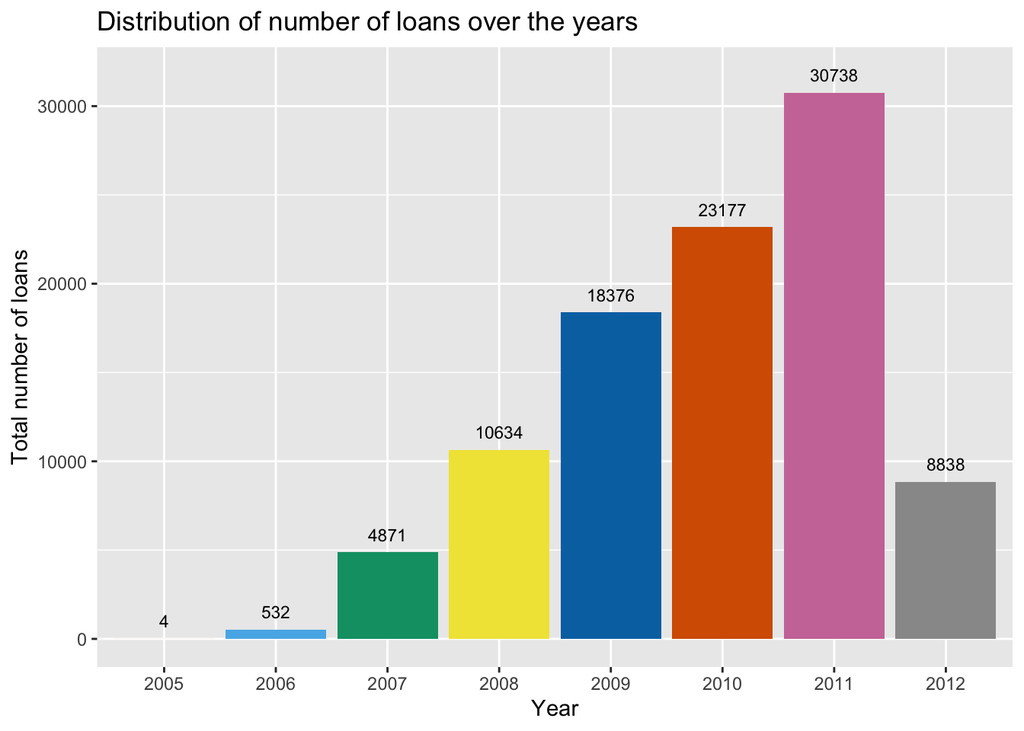

```r
# Plot loan count by year
ggplot(year_loan_count) +
  aes(x = year, y = counts, fill = year, label = counts) +
  geom_bar(stat = "identity") +
  geom_text(size = 3, nudge_y = 1000) +
  theme(legend.position = "none") +
  xlab("Year") +
  ylab("Total number of loans") +
  scale_fill_OkabeIto()+
  ggtitle("Distribution of number of loans over the years")
```

### – Loan amount and number of loans across country –

*Borrowers Distribution*

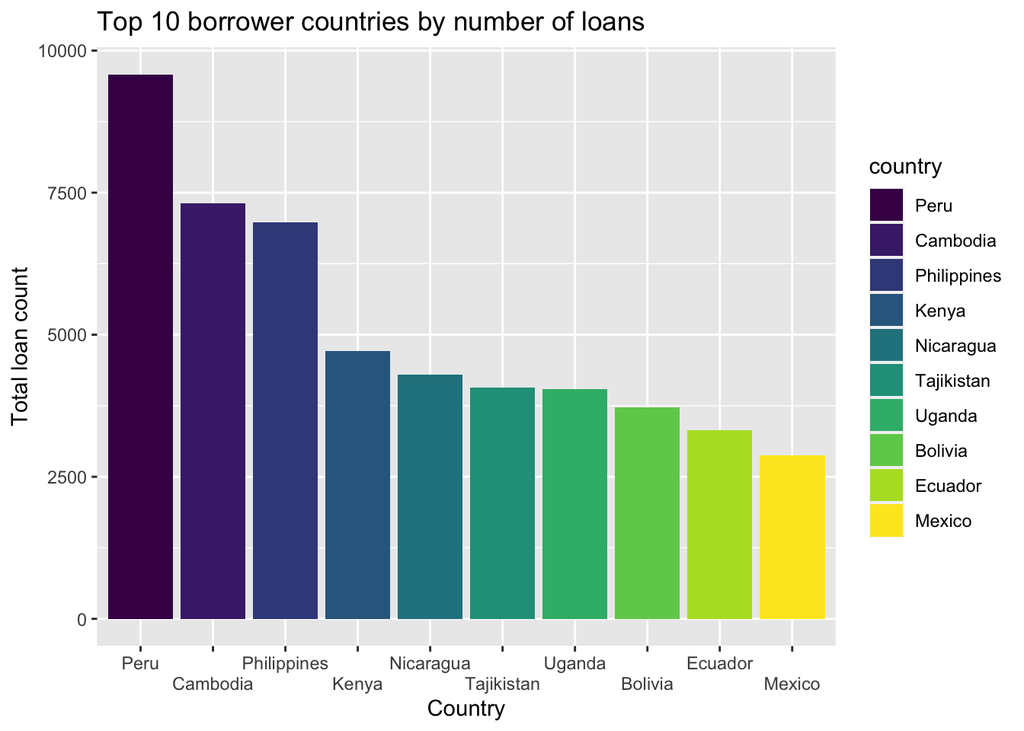

```r
# Number of Loans
loans_country <- loans %>%
  group_by(location.country) %>%
  summarize(counts = length(unique(loan_id))) %>%
  arrange(desc(counts)) %>%
  mutate(country = factor(location.country, location.country))
top_10_num_loan <- head(loans_country, 10)

# Loan Amount
tot_loans_country <- loans %>%
  group_by(location.country) %>%
  summarize(tot_loans = sum(loan_amount) / 1000) %>%
  arrange(desc(tot_loans)) %>%
  mutate(country = factor(location.country, location.country))

top_10_tot_loan <- head(tot_loans_country, 10)

par(mfrow = c(1, 1))

# Bar Chart country vs No. of loans

ggplot(top_10_num_loan) +
  geom_bar(aes(country, counts, fill = country), stat = "identity") +
  scale_x_discrete(guide = guide_axis(n.dodge = 2)) +
  xlab("Country") +
  ylab("Total loan count") +
  scale_fill_viridis(
  discrete = TRUE,
  option = "D")+
  ggtitle("Top 10 borrower countries by number of loans")
```

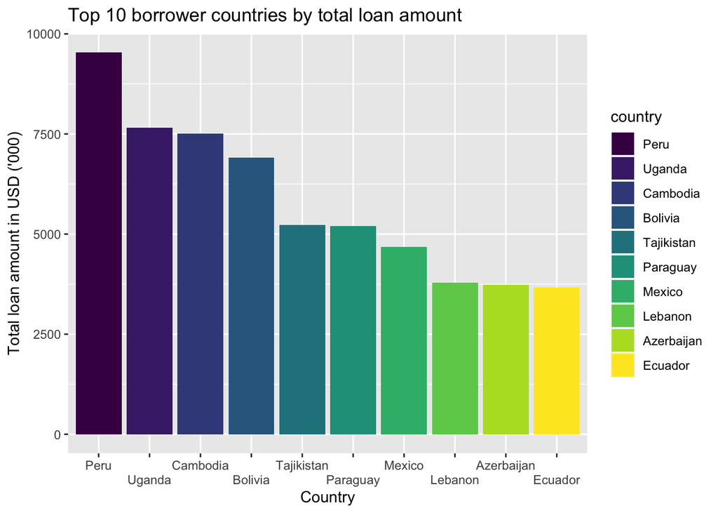

```r
# Bar Chart country was Loan Amount
ggplot(top_10_tot_loan) +
  geom_bar(aes(country, tot_loans, fill = country), stat = "identity") +
  scale_x_discrete(guide = guide_axis(n.dodge = 2)) +
  xlab("Country") +
  ylab("Total loan amount in USD ('000)") +
  scale_fill_viridis(
  discrete = TRUE,
  option = "D")+
  ggtitle("Top 10 borrower countries by total loan amount")
```

*Lenders Trend*

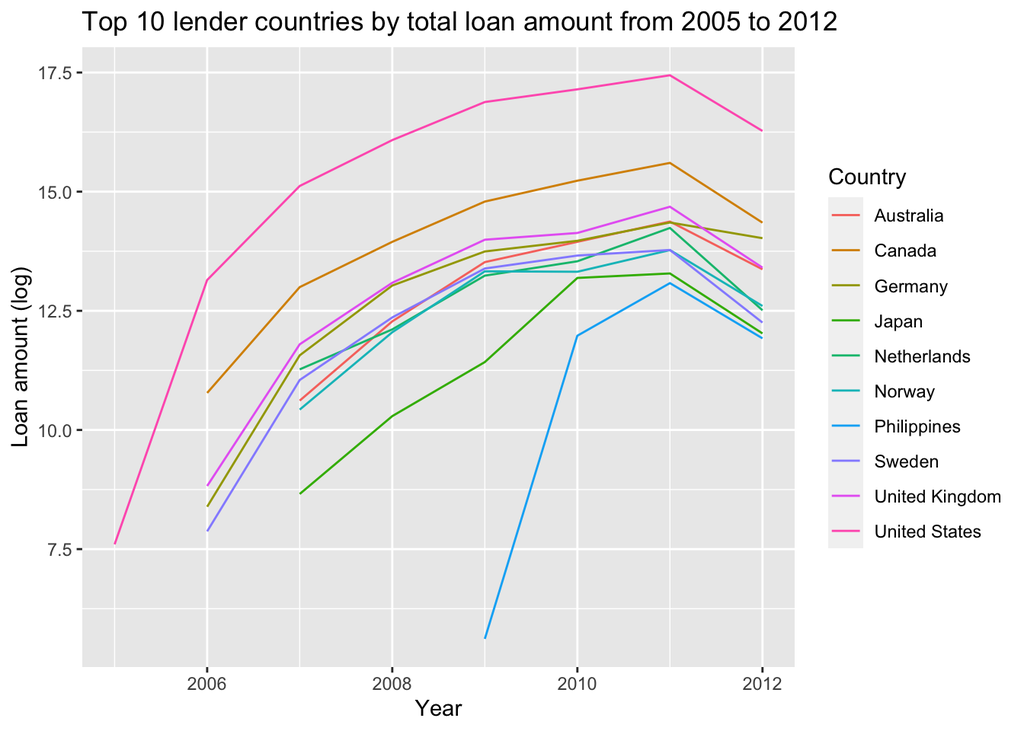

```r
country <- aggregate(lender_loans$loan_amount, by = list(year = lender_loans$posted_yr, country = lender_loans$country_code), FUN = sum, na.rm = TRUE)

country_decoded <- country %>%
  rename("country_name" = "country", "loan_amount" = "x") %>%
  filter(country_name %in% c("US", "CA", "GB", "AU", "DE", "NL", "SE", "NO", "JP", "PH")) %>%
  mutate(country_name = countrycode(country_name, "iso2c", "country.name"))

ggplot(data = country_decoded, aes(x = year, y = log(loan_amount), color = country_name)) +
  geom_line() +
  xlab("Year") +
  ylab("Loan amount (log)") +
  guides(color = guide_legend(title = "Country")) +
  scale_fill_viridis(
  discrete = TRUE,
  option = "D")+
  ggtitle("Top 10 lender countries by total loan amount from 2005 to 2012")
```

Again, here in this graph, we picked top 10 countries with the most lender based on 2011. A line graph emphasizes the trend over years. We also took a log for the loan amount. This is because US has a significantly higher total loan amount compared to other countries, due to the fact that Kiva is based in the US. As a result, a log function would make the data more comparable on a line graph. All lines peak in 2011, and drop intensely in 2012, which matches the result presented in the last two graphs.

### – Part 1: Lender Motivation –

Kiva provides a platform where borrowers can post their needs, and lenders choose who and how much to lend. As a result, whether or not a borrower gets a fund could depend on the nature of their request. On the other hand, it could also depends on lenders’ wills. In this section, we’ll mainly focus on the lenders’ characteristics. As mentioned, the most direct variable is no doubt `loan_because`.

```r
head(unique(lenders$loan_because))
```

```
## [1] "I love the stories."
## [2] NA
## [3] "it is the right thing to do."
## [4] "I want to bring hope."
## [5] "I believe in the power of everyday people to effect change, & love that, by lending just a few dollars, we can make concrete improvements in the lives of people around the world. Microfinance is amazing, & Kiva pairing it with the convenience of Paypal is... addictive!"
## [6] "It's important for all of us to help each other."
```

While the `loan_because` variable allows us to look directly at lenders self-reported motivation, analysis of this variable requires more advanced text processing which we will discuss in a later section. As a next-best option, we know look at the characteristics of borrowers in hopes of identifying patterns in lender preferences.

```r
top_lenders <- lender_loans %>%
  filter(country_code %in% c("US", "CA", "GB", "AU", "DE", "NL", "SE", "NO", "JP", "PH"))

top_lender_borrow <- aggregate(top_lenders$loan_amount, by = list(lender_country = top_lenders$country_code, borrower_country <- top_lenders$location.country), FUN = sum, na.rm = TRUE) %>%
  mutate(lender_country = countrycode(lender_country, "iso2c", "country.name")) %>%
  arrange(desc(x)) %>%
  arrange(lender_country) %>%
  group_by(lender_country) %>%
  slice(1, 2, 3) %>%
  mutate(x = format(x, big.mark = ",", trim = TRUE)) %>%
  rename("Loan Amount (USD)" = "x", "Lender Country" = "lender_country", "Borrower Country" = "Group.2")

knitr::kable(top_lender_borrow, "pipe")
```

| Lender Country | Borrower Country | Loan Amount (USD) |
| --- | --- | --- |
| Australia | Cambodia | 365,850 |
| Australia | Peru | 320,250 |
| Australia | Uganda | 307,425 |
| Canada | Peru | 1,194,675 |
| Canada | Uganda | 1,148,750 |
| Canada | Bolivia | 1,016,075 |
| Germany | Peru | 414,450 |
| Germany | Bolivia | 359,175 |
| Germany | Cambodia | 322,050 |
| Japan | Paraguay | 221,150 |
| Japan | Cambodia | 123,825 |
| Japan | Mongolia | 111,375 |
| Netherlands | Uganda | 342,450 |
| Netherlands | Peru | 314,250 |
| Netherlands | Bolivia | 234,625 |
| Norway | Uganda | 413,125 |
| Norway | Bolivia | 218,950 |
| Norway | Cambodia | 183,350 |
| Philippines | The Democratic Republic of the Congo | 241,275 |
| Philippines | Uganda | 86,925 |
| Philippines | Rwanda | 84,100 |
| Sweden | Uganda | 370,400 |
| Sweden | Bolivia | 249,525 |
| Sweden | Peru | 236,275 |
| United Kingdom | Uganda | 486,950 |
| United Kingdom | Peru | 434,800 |
| United Kingdom | Cambodia | 407,725 |
| United States | Peru | 8,718,100 |
| United States | Uganda | 7,823,575 |
| United States | Bolivia | 7,666,975 |

In the table above, we can see the top three recipient countries of each of the top ten lender countries. This graph shows that lenders may not necessarily prefer borrowers from their own countries.

### – Part 2: Repayment Factors –

#### Sector

Sector can be an important factor that explains both the lenders’ intent and the borrowers’ ability to repay. Some sectors could need more liquid capital than others, thus making up a bigger proportion of loan requests on Kiva.com. On the other hand, for lenders, some sectors could be more profitable than others, therefore more promising for lenders to get back their money.

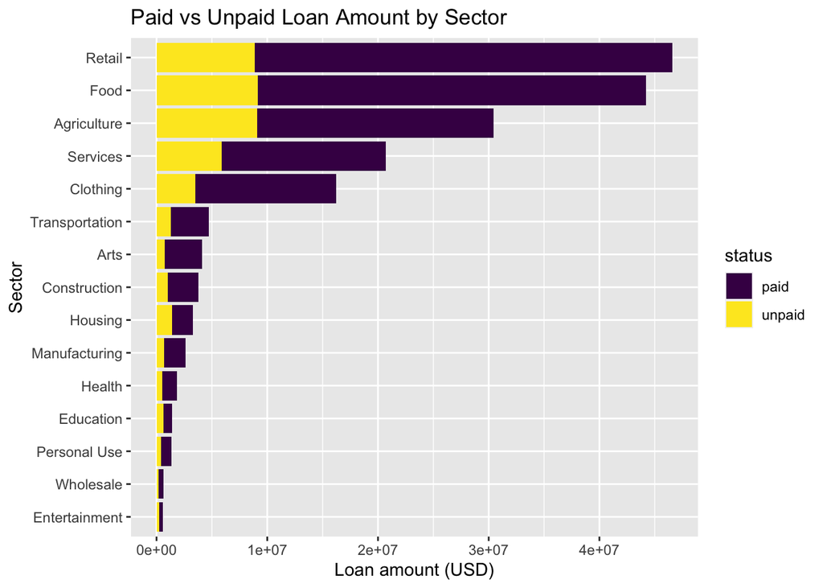

```r
sector_loan <-
  aggregate(lender_loans$loan_amount, by = list(sector = lender_loans$sector), FUN = sum)
sector_paid <-
  mutate(aggregate(lender_loans$paid_amount,
    by = list(sector = lender_loans$sector),
    FUN = sum, na.rm = TRUE
  ))

by_sector <- sector_loan %>%
  mutate(paid = sector_paid$x) %>%
  mutate(unpaid = sector_loan$x - paid) %>%
  rename(loan = x)

by_sector <- by_sector[order(by_sector$loan, decreasing = TRUE), ]
by_sector_paid <- select(by_sector, sector, paid) %>%
  mutate(status = "paid") %>%
  rename("amount" = "paid")
by_sector_unpaid <- select(by_sector, sector, unpaid) %>%
  mutate(status = "unpaid") %>%
  rename("amount" = "unpaid")
by_sector <- rbind(by_sector_paid, by_sector_unpaid) %>%
  group_by(sector)

ggplot(by_sector) +
  aes(x = reorder(sector, amount), y = amount, fill = status, label = amount) +
  geom_bar(stat = "identity", position = "stack") +
  theme() +
  coord_flip() +
  xlab("Sector") +
  ylab("Loan amount (USD)") +
  scale_fill_viridis(
  discrete = TRUE,
  option = "D")+
  ggtitle("Paid vs Unpaid Loan Amount by Sector")
```

The graph above shows that for most sector, paid loans well exceed unpaid loans. Of the top five sectors which receive the most amount of loans, Agriculture has the highest proportion of unpaid loans. Of all sectors, Housing and Education have the highest unpaid loans, nearly 50%. Whether or not sector is an important factor that predicts the the borrowers’ ability to repay the loans is thus meaningful to investigate more deeply.

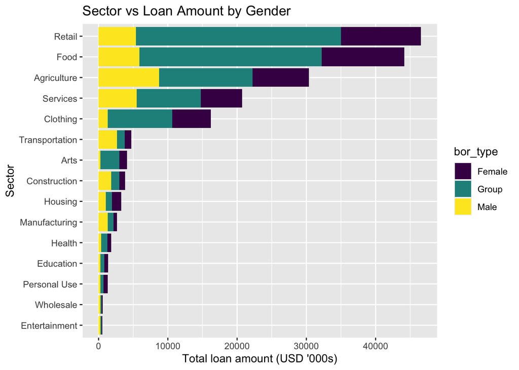

```r
# Get unique borrower id and total male female borrower count
loan_sub <- loans %>%
  group_by(borrower_image_id) %>%
  summarize(total_m = sum(borrower_m_count), total_f = sum(borrower_f_count))

# Create new borrower type column based on conditions
loan_sub <- loan_sub %>%
  mutate(bor_type = if_else(total_m == 1 & total_f == 0, "Male",
    if_else(total_m == 0 & total_f == 1, "Female", "Group")
  ))

merge <- left_join(x = lender_loans, y = loan_sub, by = "borrower_image_id")

sec_gender_loan <- merge %>%
  group_by(sector, bor_type) %>%
  summarise(tot_amount = sum(loan_amount) / 1000) %>%
  arrange(desc(tot_amount))

par(mfrow = c(1, 1))

sec_gender_loan <- na.omit(sec_gender_loan)

ggplot(sec_gender_loan) +
  aes(x = reorder(sector, tot_amount), y = tot_amount, fill = bor_type, label = tot_amount) +
  geom_bar(stat = "identity", position = "stack") +
  theme() +
  coord_flip() +
  xlab("Sector") +
  ylab("Total loan amount (USD '000s)") +
  scale_fill_viridis(
  discrete = TRUE,
  option = "D")+
  ggtitle("Sector vs Loan Amount by Gender")
```

We can replace the separate the loan amount in each sector by gender. Since total number of female borrowers far exceed that of male borrowers, in most sector, there is a greater proportion of female borrowers as well. Nevertheless, in Transportation, Construction, and Manufacturing, there are males received a higher loan amount than females.

### Conclusion

For further more in-depth analysis, it’s definitely worthy to test whether the discrepency discovered in variables in this section is statistically significant. For instance, the variability in paid vs unpaid proportion in each `sector` could reflect a potential predictor of the borrower’s ability to repay, yet it can also be due to the sheer difference in total loan amount in different sectors, as well as the economic structure in each of the borrowers’ countries. Again, EDA is the very first step to observe superficial correlation in the data, and this tutorial only shows some of the options. You can also experiment other variables or other visualization presentations, which may inspire you to a completely different direction that could catch the judges’ eyes!